# Project: Investigate a Dataset - [TMDb movie data]

- Introduction
- Data Wrangling
- Exploratory Data Analysis
- Conclusions

## Introduction

### Dataset Description

> the dataset is about TMDb movie data This data set contains information about 10,000 movies collected from The Movie Database (TMDb), including user ratings and revenue.

### Question(s) for Analysis

> Most popular Actor respect to number ofmovies most popular genres Top Most Productive Year By movies Top Most Productive Year By Profit Average runtime of each genre Runtime of movies Average runtime of All movies Average budget of moives Average revenue of Moives

```python
import pandas as pd
import numpy as np
import matplotlib.pyplot as plt
import seaborn as sns
import warnings
warnings.filterwarnings("ignore")
```

#### functions

```python
#fuction to plot boxplot
def boxplot(df,title):
    sns.set(rc = {'figure.figsize':(20,4)})
    return sns.boxplot(df['runtime']).set_title(title)
#fuction to plot barplot
def barplot(data,title,xlabel,ylabel):
    plt.figure(figsize=(20,4),dpi=100)
    plt.bar(data.index,data)
    plt.title(title)
    plt.xlabel(xlabel)
    plt.ylabel(ylabel)
    plt.show()
#function to plot line plot
def lineplot(data,title,xlabel,ylabel):
    plt.figure(figsize=(6,3),dpi=100)
    plt.title(title)
    plt.xlabel(xlabel)
    plt.ylabel(ylabel)
    plt.plot(data.index,data)
    plt.show()
```

## Data Wrangling

```python
# Load your data and print out a few lines. Perform operations to inspect data
df=pd.read_csv('tmdb-movies.csv')
df.head()
```

|  | id | imdb_id | popularity | budget | revenue | original_title | cast | homepage | director | tagline | ... | overview | runtime | genres | production_companies | release_date | vote_count | vote_average | release_year | budget_adj | revenue_adj |
| --- | --- | --- | --- | --- | --- | --- | --- | --- | --- | --- | --- | --- | --- | --- | --- | --- | --- | --- | --- | --- | --- |
| 0 | 135397 | tt0369610 | 32.985763 | 150000000 | 1513528810 | Jurassic World | Chris Pratt\|Bryce Dallas Howard\|Irrfan Khan\|Vi... | http://www.jurassicworld.com/ | Colin Trevorrow | The park is open. | ... | Twenty-two years after the events of Jurassic ... | 124 | Action\|Adventure\|Science Fiction\|Thriller | Universal Studios\|Amblin Entertainment\|Legenda... | 6/9/15 | 5562 | 6.5 | 2015 | 1.379999e+08 | 1.392446e+09 |
| 1 | 76341 | tt1392190 | 28.419936 | 150000000 | 378436354 | Mad Max: Fury Road | Tom Hardy\|Charlize Theron\|Hugh Keays-Byrne\|Nic... | http://www.madmaxmovie.com/ | George Miller | What a Lovely Day. | ... | An apocalyptic story set in the furthest reach... | 120 | Action\|Adventure\|Science Fiction\|Thriller | Village Roadshow Pictures\|Kennedy Miller Produ... | 5/13/15 | 6185 | 7.1 | 2015 | 1.379999e+08 | 3.481613e+08 |
| 2 | 262500 | tt2908446 | 13.112507 | 110000000 | 295238201 | Insurgent | Shailene Woodley\|Theo James\|Kate Winslet\|Ansel... | http://www.thedivergentseries.movie/#insurgent | Robert Schwentke | One Choice Can Destroy You | ... | Beatrice Prior must confront her inner demons ... | 119 | Adventure\|Science Fiction\|Thriller | Summit Entertainment\|Mandeville Films\|Red Wago... | 3/18/15 | 2480 | 6.3 | 2015 | 1.012000e+08 | 2.716190e+08 |
| 3 | 140607 | tt2488496 | 11.173104 | 200000000 | 2068178225 | Star Wars: The Force Awakens | Harrison Ford\|Mark Hamill\|Carrie Fisher\|Adam D... | http://www.starwars.com/films/star-wars-episod... | J.J. Abrams | Every generation has a story. | ... | Thirty years after defeating the Galactic Empi... | 136 | Action\|Adventure\|Science Fiction\|Fantasy | Lucasfilm\|Truenorth Productions\|Bad Robot | 12/15/15 | 5292 | 7.5 | 2015 | 1.839999e+08 | 1.902723e+09 |
| 4 | 168259 | tt2820852 | 9.335014 | 190000000 | 1506249360 | Furious 7 | Vin Diesel\|Paul Walker\|Jason Statham\|Michelle ... | http://www.furious7.com/ | James Wan | Vengeance Hits Home | ... | Deckard Shaw seeks revenge against Dominic Tor... | 137 | Action\|Crime\|Thriller | Universal Pictures\|Original Film\|Media Rights ... | 4/1/15 | 2947 | 7.3 | 2015 | 1.747999e+08 | 1.385749e+09 |

5 rows × 21 columns

```python
#delete some columns to get deeper into specific valuable columns
columns=['id','imdb_id','popularity','homepage','keywords','overview','production_companies','tagline','vote_count','vote_average','budget_adj','revenue_adj']
df.drop(columns,axis=1,inplace=True)
df.head(1)
```

|  | budget | revenue | original_title | cast | director | runtime | genres | release_date | release_year |
| --- | --- | --- | --- | --- | --- | --- | --- | --- | --- |
| 0 | 150000000 | 1513528810 | Jurassic World | Chris Pratt\|Bryce Dallas Howard\|Irrfan Khan\|Vi... | Colin Trevorrow | 124 | Action\|Adventure\|Science Fiction\|Thriller | 6/9/15 | 2015 |

### Data Cleaning

> we need to search for wrong datatypes

> we need to search for nulls

> we need to search for duplicate rows

> check for outlayers

> check for multiple value of columns

```python
#get info columns of dataset (non null value , datatypes)
df.info()
```

```
<class 'pandas.core.frame.DataFrame'>
RangeIndex: 10866 entries, 0 to 10865
Data columns (total 9 columns):
 #   Column          Non-Null Count  Dtype
---  ------          --------------  -----
 0   budget          10866 non-null  int64
 1   revenue         10866 non-null  int64
 2   original_title  10866 non-null  object
 3   cast            10790 non-null  object
 4   director        10822 non-null  object
 5   runtime         10866 non-null  int64
 6   genres          10843 non-null  object
 7   release_date    10866 non-null  object
 8   release_year    10866 non-null  int64
dtypes: int64(4), object(5)
memory usage: 764.1+ KB
```

#### change release_date column datatype into datatime

```python
df['release_date']=pd.to_datetime(df['release_date'])
```

#### delete null values

```python
df.isna().sum()
#delete null values
df.dropna(inplace=True)
```

#### delete duplicated rows

```python
df.duplicated().sum()
#delete duplicate rows
df.drop_duplicates(inplace=True)
```

```python
df.head(2)
```

|  | budget | revenue | original_title | cast | director | runtime | genres | release_date | release_year |
| --- | --- | --- | --- | --- | --- | --- | --- | --- | --- |
| 0 | 150000000 | 1513528810 | Jurassic World | Chris Pratt\|Bryce Dallas Howard\|Irrfan Khan\|Vi... | Colin Trevorrow | 124 | Action\|Adventure\|Science Fiction\|Thriller | 2015-06-09 | 2015 |
| 1 | 150000000 | 378436354 | Mad Max: Fury Road | Tom Hardy\|Charlize Theron\|Hugh Keays-Byrne\|Nic... | George Miller | 120 | Action\|Adventure\|Science Fiction\|Thriller | 2015-05-13 | 2015 |

#### now we need to split multiple variable column per row like cast and genres into one variable column per row

```python
#we use str.spilt to convert value of column to a list (cast column)
df['cast']=df['cast'].str.split('|')
print(df['cast'].head(2))
df['genres']=df['genres'].str.split('|')
print(df['genres'].head(2))
```

```
0    [Chris Pratt, Bryce Dallas Howard, Irrfan Khan...
1    [Tom Hardy, Charlize Theron, Hugh Keays-Byrne,...
Name: cast, dtype: object
0    [Action, Adventure, Science Fiction, Thriller]
1    [Action, Adventure, Science Fiction, Thriller]
Name: genres, dtype: object
```

```python
#create coulmn name profit = revenue-budget
df['profit']=df['revenue']-df['budget']
```

```python
#show 5 rows of data after cleaning
df.head()
```

|  | budget | revenue | original_title | cast | director | runtime | genres | release_date | release_year | profit |
| --- | --- | --- | --- | --- | --- | --- | --- | --- | --- | --- |
| 0 | 150000000 | 1513528810 | Jurassic World | [Chris Pratt, Bryce Dallas Howard, Irrfan Khan... | Colin Trevorrow | 124 | [Action, Adventure, Science Fiction, Thriller] | 2015-06-09 | 2015 | 1363528810 |
| 1 | 150000000 | 378436354 | Mad Max: Fury Road | [Tom Hardy, Charlize Theron, Hugh Keays-Byrne,... | George Miller | 120 | [Action, Adventure, Science Fiction, Thriller] | 2015-05-13 | 2015 | 228436354 |
| 2 | 110000000 | 295238201 | Insurgent | [Shailene Woodley, Theo James, Kate Winslet, A... | Robert Schwentke | 119 | [Adventure, Science Fiction, Thriller] | 2015-03-18 | 2015 | 185238201 |
| 3 | 200000000 | 2068178225 | Star Wars: The Force Awakens | [Harrison Ford, Mark Hamill, Carrie Fisher, Ad... | J.J. Abrams | 136 | [Action, Adventure, Science Fiction, Fantasy] | 2015-12-15 | 2015 | 1868178225 |
| 4 | 190000000 | 1506249360 | Furious 7 | [Vin Diesel, Paul Walker, Jason Statham, Miche... | James Wan | 137 | [Action, Crime, Thriller] | 2015-04-01 | 2015 | 1316249360 |

```python
#get info after cleaning the dataset
df.info()
```

```
<class 'pandas.core.frame.DataFrame'>
Int64Index: 10731 entries, 0 to 10865
Data columns (total 10 columns):
 #   Column          Non-Null Count  Dtype
---  ------          --------------  -----
 0   budget          10731 non-null  int64
 1   revenue         10731 non-null  int64
 2   original_title  10731 non-null  object
 3   cast            10731 non-null  object
 4   director        10731 non-null  object
 5   runtime         10731 non-null  int64
 6   genres          10731 non-null  object
 7   release_date    10731 non-null  datetime64[ns]
 8   release_year    10731 non-null  int64
 9   profit          10731 non-null  int64
dtypes: datetime64[ns](1), int64(5), object(4)
memory usage: 922.2+ KB
```

### detect outlayers and delete them

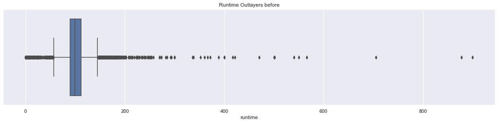

```python
#visualize outlayers with boxplot
boxplot(df,"Runtime Outlayers before");
```

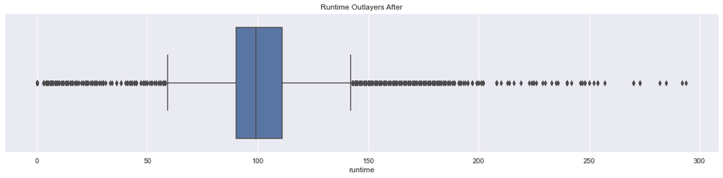

```python
#now its more resonable
df=df[df['runtime']<300]
boxplot(df,"Runtime Outlayers After");
```

```python
#print dataset shape
print('\nnow we have clean data with {} rows and {} columns in dataset we will work on'.format(df.shape[0],df.shape[1]))
```

```
now we have clean data with 10709 rows and 10 columns in dataset we will work on
```

## Exploratory Data Analysis

### Research Question 1 (Most popular Actor respect to number ofmovies)

#### As We See First 10 Most Popular Actors by movies

```python
#group by cast number of movies
df_cast=df.explode('cast').reset_index(drop=True)
MostPopularCast=df_cast.groupby('cast').count()['original_title'].sort_values(ascending=False).head(10)
MostPopularCast.head(2)
```

```
cast
Robert De Niro       72
Samuel L. Jackson    71
Name: original_title, dtype: int64
```

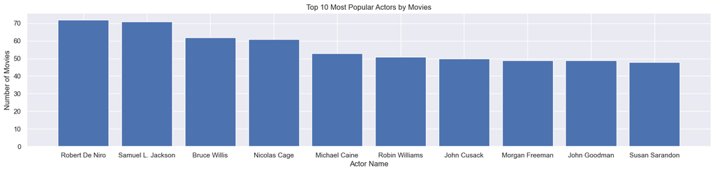

```python
#plot "Top 10 Most Popular Actors by Movies"
barplot(MostPopularCast,"Top 10 Most Popular Actors by Movies","Actor Name","Number of Movies")
```

```python
print("{} Actor that had most Number Of Movies : {} movie ".format('Robert De Niro',MostPopularCast[0]))
```

```
Robert De Niro Actor that had most Number Of Movies : 72 movie
```

### Research Question 2 (most popular genres)

```python
#group by genres types of movies
df_genre=df.explode('genres').reset_index(drop=True)
MostPopularGenre=df_genre.groupby('genres').count()['original_title'].sort_values(ascending=True)
MostPopularGenre.head(2)
```

```
genres
TV Movie    162
Western     163
Name: original_title, dtype: int64
```

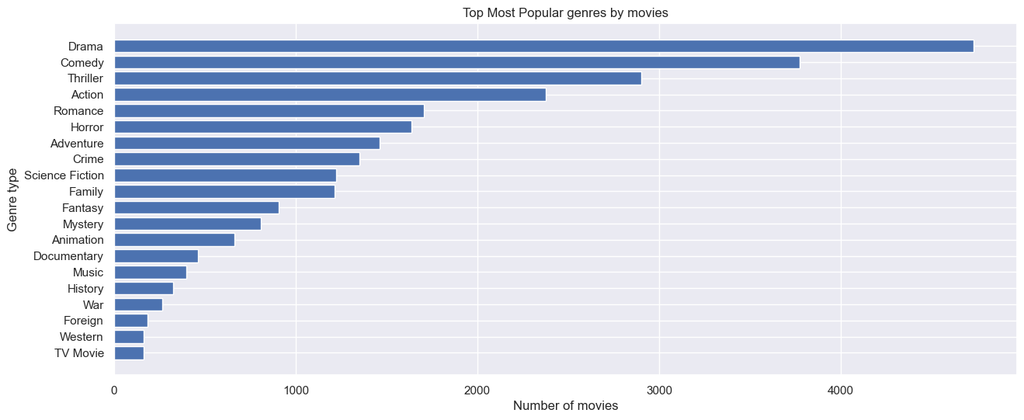

```python
#plot barh plot for 'Top Most Popular genres by movies'
plt.figure(figsize=(15,6),dpi=100)
plt.barh(MostPopularGenre.index,MostPopularGenre)
plt.title('Top Most Popular genres by movies')
plt.xlabel('Number of movies')
plt.ylabel('Genre type')
plt.show()
```

```python
print("{} Genre that had most Number Of Movies : {} movie ".format('Drama',MostPopularGenre[-1]))
```

```
Drama Genre that had most Number Of Movies : 4732 movie
```

### Research Question 3 (Top Most Productive Year By movies)

```python
#group by every year number of movies
MostProdectiveYear=df.groupby('release_year').count()['original_title']
MostProdectiveYear.head(2)
```

```
release_year
1960    32
1961    31
Name: original_title, dtype: int64
```

### Research Question 4 (Top Most Productive Year By Profit)

```python
#group by every year number of profit
MostProdectiveYearP=df.groupby('release_year')['profit'].sum()
MostProdectiveYearP.head(2)
```

```
release_year
1960    122948052
1961    291583188
Name: profit, dtype: int64
```

#### plot of question 3,4

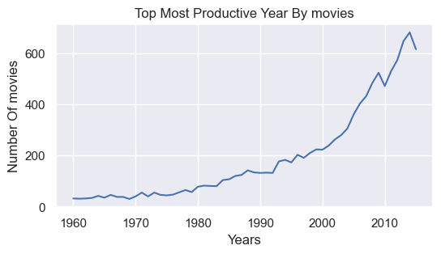

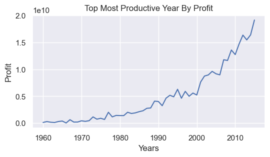

```python
#plot every year number of Movies
lineplot(MostProdectiveYear,"Top Most Productive Year By movies","Years","Number Of movies")
#plot every year number of profit
lineplot(MostProdectiveYearP,"Top Most Productive Year By Profit","Years","Profit")
```

```python
print("the year that had most Number Of Movies is {} ".format(MostProdectiveYear.idxmax()))
print("the year that had most profit is {} ".format(MostProdectiveYearP.idxmax()))
```

```
the year that had most Number Of Movies is 2014
the year that had most profit is 2015
```

### Research Question 5 (Average runtime of each genre)

```python
# get the average runtime of each genre type
Average_runtime=df_genre.groupby('genres').describe()['runtime']['mean'].sort_values(ascending=False)
Average_runtime.head(2)
```

```
genres
History    128.086687
War        122.728302
Name: mean, dtype: float64
```

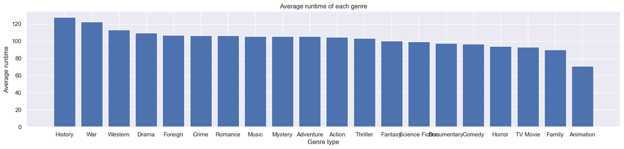

```python
#plot average runtime of each genre type
barplot(Average_runtime,'Average runtime of each genre','Genre type','Average runtime')
```

### Research Question 6 (Runtime of movies)

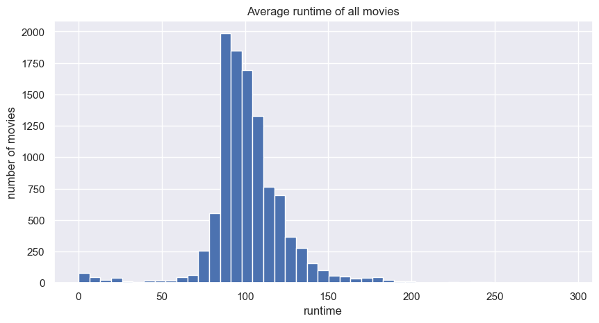

```python
#plot the histgram to see the distrubtion of run time on the number of movies
plt.figure(figsize=(10,5),dpi=100)
plt.hist(df['runtime'],bins=45)
plt.title('Average runtime of all movies')
plt.xlabel('runtime')
plt.ylabel('number of movies')
plt.show()
```

# we will run conclusions on higher or equal average profit of all movies consider it profitable movie

# we will run conclusions on less than average profit of all movies consider it non-profitable movie

```python
#save new to new dataframe by the condition >=profit average
df_prof=df[df['profit']>=df['profit'].mean()]
df_prof.head(2)
```

|  | budget | revenue | original_title | cast | director | runtime | genres | release_date | release_year | profit |
| --- | --- | --- | --- | --- | --- | --- | --- | --- | --- | --- |
| 0 | 150000000 | 1513528810 | Jurassic World | [Chris Pratt, Bryce Dallas Howard, Irrfan Khan... | Colin Trevorrow | 124 | [Action, Adventure, Science Fiction, Thriller] | 2015-06-09 | 2015 | 1363528810 |
| 1 | 150000000 | 378436354 | Mad Max: Fury Road | [Tom Hardy, Charlize Theron, Hugh Keays-Byrne,... | George Miller | 120 | [Action, Adventure, Science Fiction, Thriller] | 2015-05-13 | 2015 | 228436354 |

```python
print(df['profit'].mean()/1000000)
#save new to new dataframe by the condition <profit average
df_nonprof=df[df['profit']<df['profit'].mean()]
df_nonprof.head(2)
```

```
25.57987820113923
```

|  | budget | revenue | original_title | cast | director | runtime | genres | release_date | release_year | profit |
| --- | --- | --- | --- | --- | --- | --- | --- | --- | --- | --- |
| 11 | 176000003 | 183987723 | Jupiter Ascending | [Mila Kunis, Channing Tatum, Sean Bean, Eddie ... | Lana Wachowski\|Lilly Wachowski | 124 | [Science Fiction, Fantasy, Action, Adventure] | 2015-02-04 | 2015 | 7987720 |
| 12 | 15000000 | 36869414 | Ex Machina | [Domhnall Gleeson, Alicia Vikander, Oscar Isaa... | Alex Garland | 108 | [Drama, Science Fiction] | 2015-01-21 | 2015 | 21869414 |

### Research Question 7 (Average runtime of All movies)

```python
print(df_prof['runtime'].mean())
print(df_nonprof['runtime'].mean())
```

```
111.97083961789843
99.37190366972477
```

### Research Question 8 Average budget of moives

```python
print(df_prof['budget'].mean()/1000000)
print(df_nonprof['budget'].mean()/1000000)
```

```
46.5553148280543
7.5703446764908255
```

### Research Question 9 Average revenue of Moives

```python
print(df_prof['revenue'].mean()/1000000)
print(df_nonprof['revenue'].mean()/1000000)
```

```
191.87576565761688
5.83783767603211
```

## Conclusions

### 1-average profitable movies is >=25.6 millon

##### a -average runtime=111.9 minutes

##### b -average budget=46.5 millon

##### c -average renvenue=191.8 millon

### average Non-profitable movies is <25.6 millon

#### average runtime=99.3 minutes

#### average budget=7.5 millon

#### average renvenue=5.8 millon

### limitation

> we consider the movies two types profitable and non profitable we use the average of profit of all movies and if the movie is equal of higher than the profit average consider it profitale and if the movie is less than the profit average consider it non-profitable

```python
from subprocess import call
call(['python', '-m', 'nbconvert', 'Investigate_a_Dataset.ipynb'])
```

```
1
```